# Gradient Boost from Scratch

Kevin Patyk

11/22/2021

# Installing required packages and importing data

Loading libraries.

```r
library(xgboost) #will not use, but this is a good package for boosting
library(tree)
library(caret)
library(tidyverse)
library(randomForest)
```

Importing data and defining the predictors.

```r
#importing data
df <- mtcars

#getting names of predictors
x_vars <- names(df[, 2:ncol(df)])

#converting the names into a formula for later
x_vars <- paste(x_vars, collapse = " + ")
x_vars
```

```
## [1] "cyl + disp + hp + drat + wt + qsec + vs + am + gear + carb"
```

```r
#saving the name of the outcome variable
y_var <- colnames(df)[1]
y_var
```

```
## [1] "mpg"
```

```r
#creating the formula for later use - we will use this one but it can be done this way quickly to make formulas
formu <- as.formula(paste(y_var, "~", x_vars))
formu
```

```
## mpg ~ cyl + disp + hp + drat + wt + qsec + vs + am + gear + carb
```

# Coding the algorithm

For boosting, we need some sort of base prediction. For this base prediction, we will use the mean of the `mpg` variable, which is the outcome variable.

```r
#creating the initial prediction, which is the average of the outcome variable
df$pred_1 <- mean(df$mpg)
```

The gradient boosting algorithm can be used for predicting not only continuous target variables (as a regressor) but also for categorical target variables (as a classifier). When it is used as a regressor, the loss function is Mean Square Error (MSE) and when it is used as a classifier the loss function is Log loss.

Since we are working with a continuous outcome in this example, we will define the loss function using MSE. The objective of the algorithm here is to minimize the MSE.

This is the loss function:

```r
# this is our loss function
# y - the target variable
# yhat - the fitted values
loss <- function(y, yhat) return(mean(1/2*(y-yhat)^2))
```

Our objective is to find the minimum of this loss function, which is an adaption of the mean squared error. The algorithm exploits the fact that in a minimum there is no slope in our loss function. The gradient of our function, which is the negative partial derivative with respect to `yhat`, describes this slope. So we can actually reformulate our objective to searching a gradient of zero or close to zero to ultimately fulfill our goal of minimizing the loss.

```r
# the derivative of our loss function is the gradient
# y - the target variable
# yhat - the fitted values
gradient <- function(y, yhat) {return(y - yhat)}
```

## Round 1

Calculating the residuals for the current data using the prediction (average of `mpg` that we made earlier):

```r
df$resd_1 <- gradient(y = df$mpg, yhat = df$pred_1)
```

Now, our dataset has the initial predictions and the pseudo residuals that were calculated using the observed values and initial prediction (average of `mpg`).

```r
head(df)
```

```
##                    mpg cyl disp  hp drat    wt  qsec vs am gear carb   pred_1
## Mazda RX4         21.0   6  160 110 3.90 2.620 16.46  0  1    4    4 20.09062
## Mazda RX4 Wag     21.0   6  160 110 3.90 2.875 17.02  0  1    4    4 20.09062
## Datsun 710        22.8   4  108  93 3.85 2.320 18.61  1  1    4    1 20.09062
## Hornet 4 Drive    21.4   6  258 110 3.08 3.215 19.44  1  0    3    1 20.09062
## Hornet Sportabout 18.7   8  360 175 3.15 3.440 17.02  0  0    3    2 20.09062
## Valiant           18.1   6  225 105 2.76 3.460 20.22  1  0    3    1 20.09062
##                      resd_1
## Mazda RX4          0.909375
## Mazda RX4 Wag      0.909375
## Datsun 710         2.709375
## Hornet 4 Drive     1.309375
## Hornet Sportabout -1.390625
## Valiant           -1.990625
```

This will be the first “round” of gradient boosting. From this point, we will start predicting the residual column from our predictors.

## Round 2

In this second round, we will predict the initial residuals using the predictor variables of interest. We will do this using trees and the `tree` package.

```r
mdl <- tree(formula = resd_1 ~ cyl + disp + hp + drat + wt + qsec + vs + am + gear + carb, data = df)
summary(mdl)
```

```
##
## Regression tree:
## tree(formula = resd_1 ~ cyl + disp + hp + drat + wt + qsec +
##     vs + am + gear + carb, data = df)
## Variables actually used in tree construction:
## [1] "wt"  "cyl" "hp"
## Number of terminal nodes:  5
## Residual mean deviance:  4.023 = 108.6 / 27
## Distribution of residuals:
##    Min. 1st Qu.  Median    Mean 3rd Qu.    Max.
##  -4.067  -1.361   0.220   0.000   1.361   3.833
```

Now, we will update our previous data frame with the new predictions.

```r
df$pred_2 <- predict(mdl, df)
df$pred_2
```

```
##  [1] -0.3477679 -0.3477679  2.4893750 -0.3477679 -3.3049107 -0.3477679
##  [7] -6.6763393  2.4893750  2.4893750 -0.3477679 -0.3477679 -3.3049107
## [13] -3.3049107 -3.3049107 -6.6763393 -6.6763393 -6.6763393  9.9760417
## [19]  9.9760417  9.9760417  2.4893750 -3.3049107 -3.3049107 -6.6763393
## [25] -3.3049107  9.9760417  9.9760417  9.9760417 -6.6763393 -0.3477679
## [31] -6.6763393  2.4893750
```

Now, we have the first prediction, which it the mean of `mpg`, and the second prediction, which was made by making a regression tree where the features predicted the residuals. As we can see, the answers are currently not that great.

Now, we are going to calculate the residuals using the predictions (`df$pred_2`) we have just made using the regression tree. Keep in mind, however, that this is sequential and the previous predictions need to be taken into account. Thus, the prediction should be (`df$pred_1 + df$pred_2`).

Prior adding the predictions together, though, we need to introduce the learning rate, which will help prevent overfitting and gradually help build towards an accurate prediction. We do not want to use all of the information from the previous prediction (`df$pred_2`). So, the predictions from `df$pred_2` will be multiplied by a learning rate. The learning rate is the shrinkage you do at every step you are making and it scales from 0 to 1. Thus, we will do something like:

```r
#storing the learning rate
LR <- 0.1

#example
df$pred_1 + (LR * df$pred_2)
```

```
##  [1] 20.05585 20.05585 20.33956 20.05585 19.76013 20.05585 19.42299 20.33956
##  [9] 20.33956 20.05585 20.05585 19.76013 19.76013 19.76013 19.42299 19.42299
## [17] 19.42299 21.08823 21.08823 21.08823 20.33956 19.76013 19.76013 19.42299
## [25] 19.76013 21.08823 21.08823 21.08823 19.42299 20.05585 19.42299 20.33956
```

Now, we have to update our residuals based on the previous 2 predictions.

```r
df$resd_2 <- (df$mpg - (df$pred_1 + (LR * df$pred_2)))
df$resd_2
```

```
##  [1]  0.9441518  0.9441518  2.4604375  1.3441518 -1.0601339 -1.9558482
##  [7] -5.1229911  4.0604375  2.4604375 -0.8558482 -2.2558482 -3.3601339
## [13] -2.4601339 -4.5601339 -9.0229911 -9.0229911 -4.7229911 11.3117708
## [19]  9.3117708 12.8117708  1.1604375 -4.2601339 -4.5601339 -6.1229911
## [25] -0.5601339  6.2117708  4.9117708  9.3117708 -3.6229911 -0.3558482
## [31] -4.4229911  1.0604375
```

## Round 3

Now, we have our second set of residuals. Now, we will predict the residuals (`df$resd_2`) we obtained in the second round using the predictors of interest. Again, using the `tree` package to make a regression tree.

```r
mdl_2 <- tree(formula = resd_2 ~ cyl + disp + hp + drat + wt + qsec + vs + am + gear + carb, data = df)
summary(mdl_2)
```

```
##
## Regression tree:
## tree(formula = resd_2 ~ cyl + disp + hp + drat + wt + qsec +
##     vs + am + gear + carb, data = df)
## Variables actually used in tree construction:
## [1] "wt"  "cyl" "hp"
## Number of terminal nodes:  5
## Residual mean deviance:  4.023 = 108.6 / 27
## Distribution of residuals:
##    Min. 1st Qu.  Median    Mean 3rd Qu.    Max.
##  -4.067  -1.361   0.220   0.000   1.361   3.833
```

Now, using the model we made to predict `resd_2`, we will make new predictions.

```r
df$pred_3 <- predict(mdl_2, df)
df$pred_3
```

```
##  [1] -0.3129911 -0.3129911  2.2404375 -0.3129911 -2.9744196 -0.3129911
##  [7] -6.0087054  2.2404375  2.2404375 -0.3129911 -0.3129911 -2.9744196
## [13] -2.9744196 -2.9744196 -6.0087054 -6.0087054 -6.0087054  8.9784375
## [19]  8.9784375  8.9784375  2.2404375 -2.9744196 -2.9744196 -6.0087054
## [25] -2.9744196  8.9784375  8.9784375  8.9784375 -6.0087054 -0.3129911
## [31] -6.0087054  2.2404375
```

Then, our third residuals will be the actual values for `mpg` minus the combination of predictions for the current round (3) and the previous rounds (1 & 2).

```r
df$resd_3 <- (df$mpg - (df$pred_1 + (LR * df$pred_2) + (LR * df$pred_3)))
df$resd_3
```

```
##  [1]  0.9754509  0.9754509  2.2363938  1.3754509 -0.7626920 -1.9245491
##  [7] -4.5221205  3.8363937  2.2363938 -0.8245491 -2.2245491 -3.0626920
## [13] -2.1626920 -4.2626920 -8.4221205 -8.4221205 -4.1221205 10.4139271
## [19]  8.4139271 11.9139271  0.9363938 -3.9626920 -4.2626920 -5.5221205
## [25] -0.2626920  5.3139271  4.0139271  8.4139271 -3.0221205 -0.3245491
## [31] -3.8221205  0.8363937
```

So, this is the idea behind gradient boosting:

- First, make an initial prediction using the average of the outcome variable.
- Then, calculate the residuals using the initial prediction.
- Then, fit a tree predicting the residuals by the predictor variables.
- Then, use the tree to make new predictions.
- Finally, calculate the residuals by subtracting the sum of the previous predictions (with learning rates included) from the observed values.
- This process stops until some stopping criterion is reached.

# Using a `for` loop

We used the step-by-step procedure to understand the basic idea behind boosting. Now, we will be using a `for` loop to iterate through these steps rather than typing it all manually.

```r
#storing the data frame
df <- mtcars

#defining the x variables
x_vars <- names(df[, 2:ncol(df)])
x_vars <- paste(x_vars, collapse = " + ")

#gradient function
gradient <- function(y, yhat) {return(y - yhat)}

#let us define how many rounds we are going to do; in this example, we will do 10
nrounds <- 10

#learning rate
LR <- 0.1

#now, we are going to make a data frame column that hold the prediction for each round
prediction <- NA
df <- cbind(df[1], prediction, df[2:ncol(df)])

#round 1
df$pred_1 <- mean(df$mpg)
df$prediction <-df$pred_1
df$resd_1 <- gradient(df$mpg, df$prediction)

#rmse using the caret package
rmse <- RMSE(df$mpg, df$prediction)
result <- data.frame("Round" = c(1), "RMSE" = c(rmse))

#now, making the for loop
for(i in 2:nrounds){

  mdl <- eval(parse(text = paste0("tree(resd_", i-1, "~", x_vars, ", data=df)")))
  df[[paste0("pred_", i)]] <- predict(mdl, df)

  df$prediction <- df$prediction + (LR * df[[paste0("pred_", i)]])
  df[[paste0("resd_", i)]] <- gradient(y = df$mpg, yhat = df$prediction)

  rmse <- RMSE(df$mpg, df$prediction)
  result <- rbind(result, list("Round" = i, "RMSE" = rmse))

}

result
```

```
##    Round     RMSE
## 1      1 5.932030
## 2      2 5.398886
## 3      3 4.924913
## 4      4 4.504583
## 5      5 4.132896
## 6      6 3.781081
## 7      7 3.470061
## 8      8 3.197319
## 9      9 2.956718
## 10    10 2.742473
```

As we can see, the RMSE decreases with every round, which is what we expect and what are we hoping to see. As a reminder, RMSE:

Root Mean Square Error (RMSE) is the standard deviation of the residuals (prediction errors). Residuals are a measure of how far from the regression line data points are; RMSE is a measure of how spread out these residuals are. In other words, it tells you how concentrated the data is around the line of best fit.

*NOTE*: This is not how gradient boosting is actually in practice. If we wanted to perform boosting, we can use the package `xgboost`. This has been kept simple just go generate understanding.

# Making it into a function

Now, we will take the code from the previous section and turn it into a function. This function will not be adaptable to other datasets, but will make it easier to make examples for plots later.

```r
gradboost <- function(data, nrounds, LR){
  #defining the data
  df <- data

  #defining the x variables
  x_vars <- names(df[, 2:ncol(df)])
  x_vars <- paste(x_vars, collapse = " + ")

  #defining the number of rounds
  nrounds <- nrounds

  #defining the learning rate
  LR <- LR

  #creating the gradient function
  gradient <- function(y, yhat) {return(y - yhat)}

  #now, we are going to make a data frame column that hold the prediction for each round
  prediction <- NA
  df <- cbind(df[1], prediction, df[2:ncol(df)])

  #performing round 1 using the average of the outcome (mpg)
  df$pred_1 <- mean(df$mpg)
  df$prediction <- df$pred_1
  df$resd_1 <- gradient(df$mpg, df$prediction)

  #initializing the rmse/results
  #rmse using the caret package
  rmse <- RMSE(df$mpg, df$prediction)
  result <- data.frame("Round" = c(1), "RMSE" = c(rmse))

  #finally, the for loop
  for(i in 2:nrounds){

  mdl <- eval(parse(text = paste0("tree(resd_", i-1, "~", x_vars, ", data=df)")))
  df[[paste0("pred_", i)]] <- predict(mdl, df)

  df$prediction <- df$prediction + (LR * df[[paste0("pred_", i)]])
  df[[paste0("resd_", i)]] <- gradient(y = df$mpg, yhat = df$prediction)

  rmse <- RMSE(df$mpg, df$prediction)
  result <- rbind(result, list("Round" = i, "RMSE" = rmse))

  }
  return(result)
}
```

Now, to make sure the function works properly.

```r
gradboost(data = mtcars, nrounds = 10, LR = 0.1)
```

```
##    Round     RMSE
## 1      1 5.932030
## 2      2 5.398886
## 3      3 4.924913
## 4      4 4.504583
## 5      5 4.132896
## 6      6 3.781081
## 7      7 3.470061
## 8      8 3.197319
## 9      9 2.956718
## 10    10 2.742473
```

The function does work properly.

# Comparing methods

Now, we will compare methods just as an example to see what the results look like.

```r
#basic tree model
tree_mdl <- eval(parse(text = paste0("tree(mpg", "~", x_vars, ", data=df)")))
prediction <- predict(tree_mdl, df)
tree_rmse <- RMSE(df$mpg, prediction)

#random forest
rf_mdl <- eval(parse(text = paste0("randomForest(mpg", "~", x_vars, ", data=df)")))
prediction_rf <- predict(rf_mdl, df)
rf_rmse <- RMSE(df$mpg, prediction_rf)
```

Now, we will use `ggplot2` to visualize these RMSE scores.

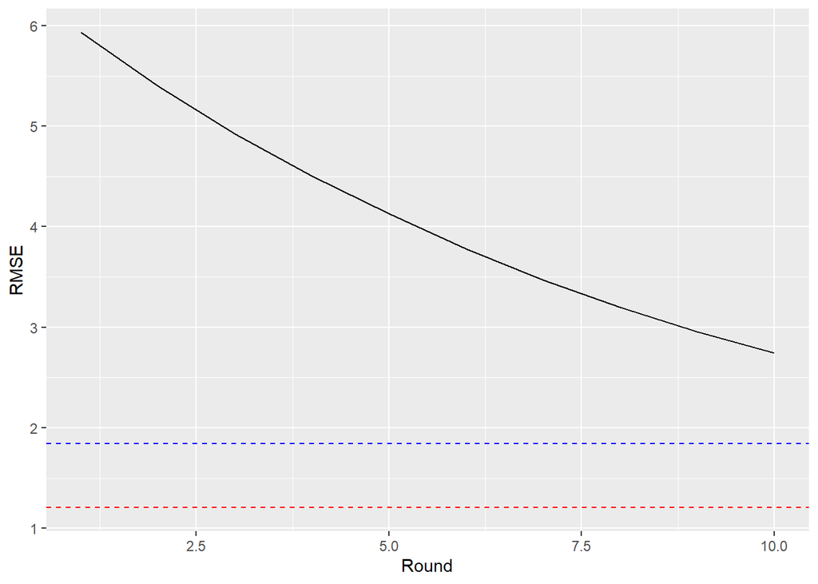

```r
ggplot() +
  geom_line(data = result, aes(x = Round, y = RMSE)) +
  geom_hline(yintercept = tree_rmse, color = "blue", linetype = "dashed") +
  geom_hline(yintercept = rf_rmse, color = "red", linetype = "dashed")
```

Although it looks like our gradient boosting method did not do so well, keep in mind that we only set it to 10 rounds, this is a very basic implementation of the algorithm, and we are not using training/testing sets. If we increased the number of rounds and change up the learning rate, the RMSE would continue to drop, eventually becoming equal to or lower than the RMSE values provided by the basic decision tree and the random forest.

Below is an example graph with 20 rounds rather than 10:

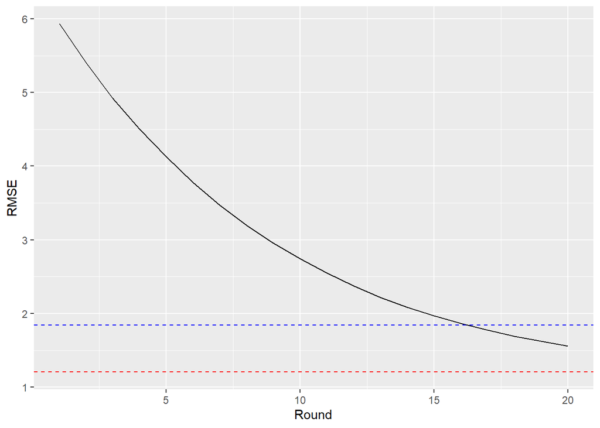

```r
result_2 <- gradboost(data = mtcars, nrounds = 20, LR = 0.1)

ggplot() +
  geom_line(data = result_2, aes(x = Round, y = RMSE)) +
  geom_hline(yintercept = tree_rmse, color = "blue", linetype = "dashed") +
  geom_hline(yintercept = rf_rmse, color = "red", linetype = "dashed")
```

And with 30 rounds:

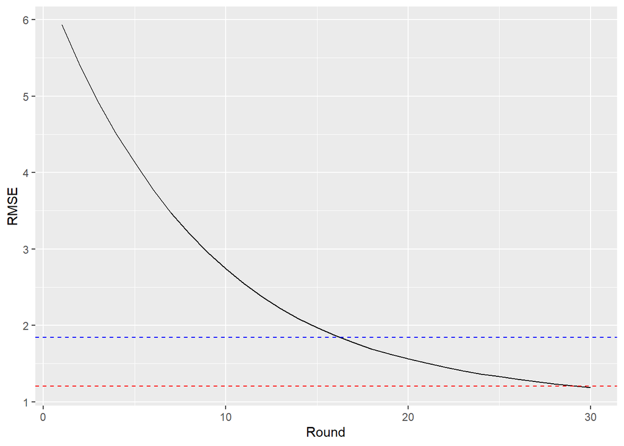

```r
result_3 <- gradboost(data = mtcars, nrounds = 30, LR = 0.1)

ggplot() +
  geom_line(data = result_3, aes(x = Round, y = RMSE)) +
  geom_hline(yintercept = tree_rmse, color = "blue", linetype = "dashed") +
  geom_hline(yintercept = rf_rmse, color = "red", linetype = "dashed")
```